# SVM exploratory analysis

Load the data and metadata. In this analysis, I will be using the cleaned RPKM data.

Load libraries:

```r
library(kernlab)
library(cvTools)
library(edgeR)
library(caret)
library(plyr)
library(limma)
library(VennDiagram)
library(xtable)
rDes <- read.delim("../../data/experimental_design_cleaned.txt")
rownames(rDes) <- rDes$TCGA_patient_id
rDat <- read.delim("../../data/aml.rnaseq.gaf2.0_rpkm_cleaned.txt", row.names = 1,
    check.names = FALSE)

all.results <- list()
```

## 1) Functions for cross-validation

```r
# Function to select features using linear models input.dat: training data
# set input.labels: true outcomes for training data
fs.lm <- function(input.dat, input.labels) {
    norm.factor <- calcNormFactors(input.dat)
    design <- model.matrix(~input.labels)
    colnames(design) <- c("Intercept", "Label")
    dat.voomed <- voom(input.dat, design, lib.size = colSums(input.dat) * norm.factor)
    fit <- lmFit(dat.voomed, design)
    ebFit <- eBayes(fit)
    hits <- topTable(ebFit, n = Inf, coef = "Label")
    train.features <- hits$ID[1:25]
    # train.features <- rownames(hits)[1:25]
    return(train.features)
}
```

```r
# Function to choose features using correlations to outcomes input.dat:
# training data set input.labels: true outcomes for training data
fs.corr <- function(input.dat, input.levels) {
    gene.corrs <- apply(input.dat, 1, function(x) return(suppressWarnings(cor(x,
        as.numeric(input.levels), method = "spearman"))))
    gene.corrs <- gene.corrs[order(abs(gene.corrs), na.last = NA, decreasing = TRUE)]
    return(names(gene.corrs[1:25]))
}
```

```r
# Function to run k-fold cross validation with svm all.dat: all data used in
# the analysis all.labels: true outcomes for the data K: number of folds to
# use in CV fs.method: the strategy to use for feature selection
svm.cv <- function(all.dat, all.labels, all.levels, K = 5, fs.method = "lm",
    conf.mat.flip = FALSE) {
    set.seed(540)
    folds <- cvFolds(ncol(all.dat), K = K)

    conf_matrix <- matrix(0, nrow = 2, ncol = 2, dimnames = list(c("true0",
        "true1"), c("pred0", "pred1")))
    feature.list <- list()

    for (f in 1:K) {
        train.samples <- folds$subsets[folds$which != f, ]
        test.samples <- folds$subsets[folds$which == f, ]

        if (fs.method == "lm") {
            train.features <- fs.lm(all.dat[, train.samples], all.labels[train.samples])
        } else if (fs.method == "corr") {
            train.features <- fs.corr(all.dat[, train.samples], all.levels[train.samples])
        }
        feature.list[[paste("Fold", f, sep = "")]] <- train.features

        train.dat <- data.frame(class = all.labels[train.samples], t(all.dat[train.features,
            train.samples]))
        test.dat <- data.frame(t(all.dat[train.features, test.samples]))
        test.labels <- all.labels[test.samples]

        fit.svm <- ksvm(class ~ ., train.dat)

        pred.svm <- predict(fit.svm, newdata = test.dat, type = "response")

        results <- table(factor(test.labels, levels = c(0, 1)), factor(pred.svm,
            levels = c(0, 1)), dnn = c("obs", "pred"))

        if (conf.mat.flip) {
            conf_matrix[2, 2] <- conf_matrix[2, 2] + results[1, 1]
            conf_matrix[2, 1] <- conf_matrix[2, 1] + results[1, 2]
            conf_matrix[1, 2] <- conf_matrix[1, 2] + results[2, 1]
            conf_matrix[1, 1] <- conf_matrix[1, 1] + results[2, 2]
        } else {
            conf_matrix[1, 1] <- conf_matrix[1, 1] + results[1, 1]
            conf_matrix[1, 2] <- conf_matrix[1, 2] + results[1, 2]
            conf_matrix[2, 1] <- conf_matrix[2, 1] + results[2, 1]
            conf_matrix[2, 2] <- conf_matrix[2, 2] + results[2, 2]
        }
    }

    svm.sens <- conf_matrix[2, 2]/sum(conf_matrix[2, ])
    svm.spec <- conf_matrix[1, 1]/sum(conf_matrix[1, ])
    svm.acc <- (conf_matrix[1, 1] + conf_matrix[2, 2])/sum(conf_matrix)

    return(list(acc = svm.acc, sens = svm.sens, spec = svm.spec, feature.list = feature.list))
}
```

## 2) Train svm to predict cytogenetic risk, use linear models for feature selection

Set up the data. Remove samples where the cytogenetic risk category is not determined, and set categories to poor and not poor:

```r
svmDes <- rDes[rDes$Cytogenetic_risk != "N.D.", ]
svm.labels <- mapvalues(svmDes$Cytogenetic_risk, c("Good", "Intermediate", "Poor"),
    c(0, 0, 1), warn_missing = TRUE)
svm.labels <- factor(svm.labels)
svm.levels <- mapvalues(svmDes$Cytogenetic_risk, c("Good", "Intermediate", "Poor"),
    c(3, 2, 1), warn_missing = TRUE)
svm.levels <- factor(svm.levels)
svmDat <- rDat[, rownames(svmDes)]
```

Run a 5-fold cross-validation for the data:

```r
cv.risk.res <- svm.cv(svmDat, svm.labels, svm.levels, K = 5, fs.method = "lm")
```

```
## Using automatic sigma estimation (sigest) for RBF or laplace kernel
## Using automatic sigma estimation (sigest) for RBF or laplace kernel
## Using automatic sigma estimation (sigest) for RBF or laplace kernel
## Using automatic sigma estimation (sigest) for RBF or laplace kernel
## Using automatic sigma estimation (sigest) for RBF or laplace kernel
```

```r
cv.risk.res[1:3]
```

```
## $acc
## [1] 0.858
##
## $sens
## [1] 0.5476
##
## $spec
## [1] 0.9552
```

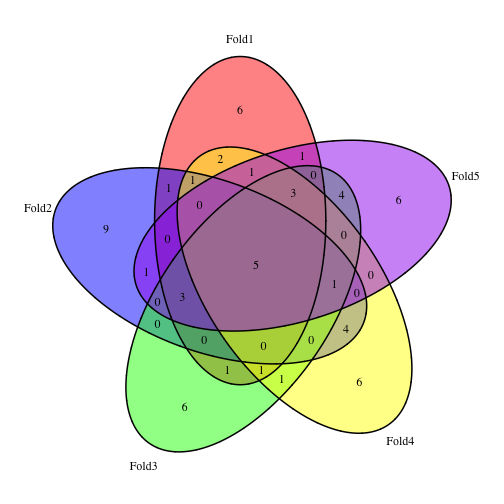

```r
all.results[["lm.poor"]] <- cv.risk.res[1:3]
fts <- cv.risk.res[[4]]

plot.new()
venn.plot <- venn.diagram(fts, filename = NULL, fill = c("red", "blue", "green",
    "yellow", "purple"), margin = 0.1)
grid.draw(venn.plot)
```

```r
(common.fts.risk <- intersect(fts[[1]], intersect(fts[[2]], intersect(fts[[3]],
    intersect(fts[[4]], fts[[5]])))))
```

```
## [1] "SCD|6319_calculated"     "STYXL1|51657_calculated"
## [3] "PDAP1|11333_calculated"  "LUC7L2|51631_calculated"
## [5] "GSTK1|373156_calculated"
```

## 3) Predict the different cytogenetic mutations, use linear models for feature selection

First look at trisomy 8:

```r
cv.trisomy8.res <- svm.cv(rDat, factor(as.numeric(rDes$trisomy_8)), svm.levels,
    K = 5, fs.method = "lm")
```

```
## Using automatic sigma estimation (sigest) for RBF or laplace kernel
## Using automatic sigma estimation (sigest) for RBF or laplace kernel
## Using automatic sigma estimation (sigest) for RBF or laplace kernel
## Using automatic sigma estimation (sigest) for RBF or laplace kernel
## Using automatic sigma estimation (sigest) for RBF or laplace kernel
```

```r
cv.trisomy8.res[1:3]
```

```
## $acc
## [1] 0.9385
##
## $sens
## [1] 0.6842
##
## $spec
## [1] 0.9688
```

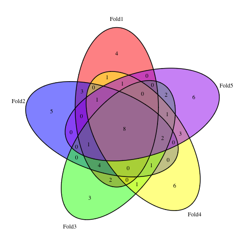

```r
all.results[["lm.trisomy8"]] <- cv.trisomy8.res[1:3]
fts <- cv.trisomy8.res[[4]]

plot.new()
venn.plot <- venn.diagram(fts, filename = NULL, fill = c("red", "blue", "green",
    "yellow", "purple"), margin = 0.1)
grid.draw(venn.plot)
```

```r
(common.fts.trisomy8 <- intersect(fts[[1]], intersect(fts[[2]], intersect(fts[[3]],
    intersect(fts[[4]], fts[[5]])))))
```

```
## [1] "NEIL2|252969_calculated"   "PPP2R2A|5520_calculated"
## [3] "ZNF7|7553_calculated"      "KIAA1967|57805_calculated"
## [5] "R3HCC1|203069_calculated"  "TSNARE1|203062_calculated"
## [7] "C8orf55|51337_calculated"  "ZFP41|286128_calculated"
```

Next look at deletions of chromosome 5:

```r
cv.del5.res <- svm.cv(rDat, factor(as.numeric(rDes$del_5)), svm.levels, K = 5,
    fs.method = "lm")
```

```
## Using automatic sigma estimation (sigest) for RBF or laplace kernel
## Using automatic sigma estimation (sigest) for RBF or laplace kernel
## Using automatic sigma estimation (sigest) for RBF or laplace kernel
## Using automatic sigma estimation (sigest) for RBF or laplace kernel
## Using automatic sigma estimation (sigest) for RBF or laplace kernel
```

```r
cv.del5.res[1:3]
```

```
## $acc
## [1] 0.9553
##
## $sens
## [1] 0.625
##
## $spec
## [1] 0.9877
```

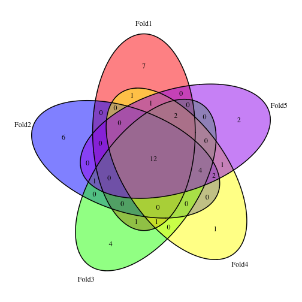

```r
all.results[["lm.del5"]] <- cv.del5.res[1:3]
fts <- cv.del5.res[[4]]

plot.new()
venn.plot <- venn.diagram(fts, filename = NULL, fill = c("red", "blue", "green",
    "yellow", "purple"), margin = 0.1)
grid.draw(venn.plot)
```

```r
(common.fts.del5 <- intersect(fts[[1]], intersect(fts[[2]], intersect(fts[[3]],
    intersect(fts[[4]], fts[[5]])))))
```

```
##  [1] "KDM3B|51780_calculated"        "EIF4EBP3|8637_calculated"
##  [3] "PCBD2|84105_calculated"        "KIAA0141|9812|1of2_calculated"
##  [5] "PFDN1|5201_calculated"         "RBM22|55696_calculated"
##  [7] "ZMAT2|153527_calculated"       "CSNK1A1|1452_calculated"
##  [9] "PPP2CA|5515_calculated"        "WDR55|54853_calculated"
## [11] "CATSPER3|347732_calculated"    "HARS|3035_calculated"
```

Next look at deletions of chromosome 7:

```r
cv.del7.res <- svm.cv(rDat, factor(as.numeric(rDes$del_7)), svm.levels, K = 5,
    fs.method = "lm")
```

```
## Using automatic sigma estimation (sigest) for RBF or laplace kernel
## Using automatic sigma estimation (sigest) for RBF or laplace kernel
## Using automatic sigma estimation (sigest) for RBF or laplace kernel
## Using automatic sigma estimation (sigest) for RBF or laplace kernel
## Using automatic sigma estimation (sigest) for RBF or laplace kernel
```

```r
cv.del7.res[1:3]
```

```
## $acc
## [1] 0.9553
##
## $sens
## [1] 0.7143
##
## $spec
## [1] 0.9873
```

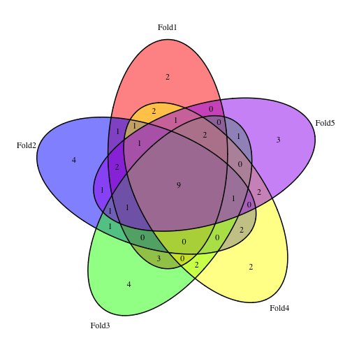

```r
all.results[["lm.del7"]] <- cv.del7.res[1:3]
fts <- cv.del7.res[[4]]

plot.new()
venn.plot <- venn.diagram(fts, filename = NULL, fill = c("red", "blue", "green",
    "yellow", "purple"), margin = 0.1)
grid.draw(venn.plot)
```

```r
(common.fts.del7 <- intersect(fts[[1]], intersect(fts[[2]], intersect(fts[[3]],
    intersect(fts[[4]], fts[[5]])))))
```

```
## [1] "LUC7L2|51631_calculated"   "PDAP1|11333_calculated"
## [3] "MKRN1|23608_calculated"    "SLC25A13|10165_calculated"
## [5] "GATAD1|57798_calculated"   "GSTK1|373156_calculated"
## [7] "STYXL1|51657_calculated"   "SUMF2|25870_calculated"
## [9] "CASP2|835_calculated"
```

Now get a sense of how many genes are shared between these 4 different sets:

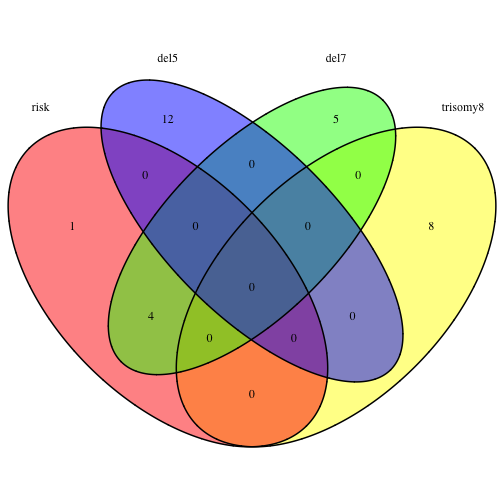

```r
fts.all <- list(risk = common.fts.risk, trisomy8 = common.fts.trisomy8, del5 = common.fts.del5,
    del7 = common.fts.del7)
plot.new()
venn.plot <- venn.diagram(fts.all, filename = NULL, fill = c("red", "yellow",
    "blue", "green"))
grid.draw(venn.plot)
```

## 4) Train svm to predict cytogenetic risk, use correlations for feature selection

Run a 5-fold cross-validation for the data:

```r
cv.risk.res <- svm.cv(svmDat, svm.labels, svm.levels, K = 5, fs.method = "corr")
```

```
## Using automatic sigma estimation (sigest) for RBF or laplace kernel
## Using automatic sigma estimation (sigest) for RBF or laplace kernel
## Using automatic sigma estimation (sigest) for RBF or laplace kernel
## Using automatic sigma estimation (sigest) for RBF or laplace kernel
## Using automatic sigma estimation (sigest) for RBF or laplace kernel
```

```r
cv.risk.res[1:3]
```

```
## $acc
## [1] 0.8239
##
## $sens
## [1] 0.4524
##
## $spec
## [1] 0.9403
```

```r
all.results[["corr.poor"]] <- cv.risk.res[1:3]
fts <- cv.risk.res[[4]]

plot.new()
venn.plot <- venn.diagram(fts, filename = NULL, fill = c("red", "blue", "green",
    "yellow", "purple"), margin = 0.1)
grid.draw(venn.plot)
```

[output not shown]

```r
(common.fts.risk <- intersect(fts[[1]], intersect(fts[[2]], intersect(fts[[3]],
    intersect(fts[[4]], fts[[5]])))))
```

```
## [1] "PDE4DIP|9659_calculated"  "PHKA1|5255_calculated"
## [3] "SDPR|8436_calculated"     "RECK|8434_calculated"
## [5] "IL7|3574_calculated"      "STARD10|10809_calculated"
```

## 5) Predict the different cytogenetic mutations, use correlations for feature selection

First look at trisomy 8:

```r
cv.trisomy8.res <- svm.cv(rDat, factor(as.numeric(rDes$trisomy_8)), factor(as.numeric(rDes$trisomy_8)),
    K = 5, fs.method = "corr")
```

```
## Using automatic sigma estimation (sigest) for RBF or laplace kernel
## Using automatic sigma estimation (sigest) for RBF or laplace kernel
## Using automatic sigma estimation (sigest) for RBF or laplace kernel
## Using automatic sigma estimation (sigest) for RBF or laplace kernel
## Using automatic sigma estimation (sigest) for RBF or laplace kernel
```

```r
cv.trisomy8.res[1:3]
```

```
## $acc
## [1] 0.9441
##
## $sens
## [1] 0.5789
##
## $spec
## [1] 0.9875
```

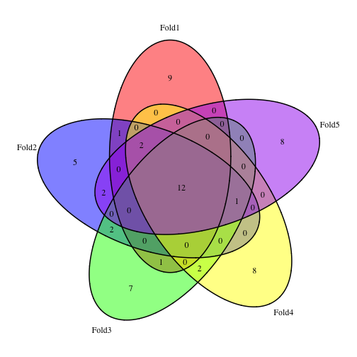

```r
all.results[["corr.trisomy8"]] <- cv.trisomy8.res[1:3]
fts <- cv.trisomy8.res[[4]]

plot.new()
venn.plot <- venn.diagram(fts, filename = NULL, fill = c("red", "blue", "green",
    "yellow", "purple"), margin = 0.1)
grid.draw(venn.plot)
```

```r
(common.fts.trisomy8 <- intersect(fts[[1]], intersect(fts[[2]], intersect(fts[[3]],
    intersect(fts[[4]], fts[[5]])))))
```

```
##  [1] "NEIL2|252969_calculated"   "KIAA1967|57805_calculated"
##  [3] "R3HCC1|203069_calculated"  "DOCK5|80005_calculated"
##  [5] "BIN3|55909_calculated"     "POLR3D|661_calculated"
##  [7] "PPP2R2A|5520_calculated"   "TSNARE1|203062_calculated"
##  [9] "ZNF7|7553_calculated"      "HEATR7A|727957_calculated"
## [11] "COMMD5|28991_calculated"   "IKBKB|3551_calculated"
```

Next look at deletions of chromosome 5:

```r
cv.del5.res <- svm.cv(rDat, factor(as.numeric(rDes$del_5)), factor(as.numeric(rDes$del_5)),
    K = 5, fs.method = "corr")
```

```
## Using automatic sigma estimation (sigest) for RBF or laplace kernel
## Using automatic sigma estimation (sigest) for RBF or laplace kernel
## Using automatic sigma estimation (sigest) for RBF or laplace kernel
## Using automatic sigma estimation (sigest) for RBF or laplace kernel
## Using automatic sigma estimation (sigest) for RBF or laplace kernel
```

```r
cv.del5.res[1:3]
```

```
## $acc
## [1] 0.9218
##
## $sens
## [1] 0.1875
##
## $spec
## [1] 0.9939
```

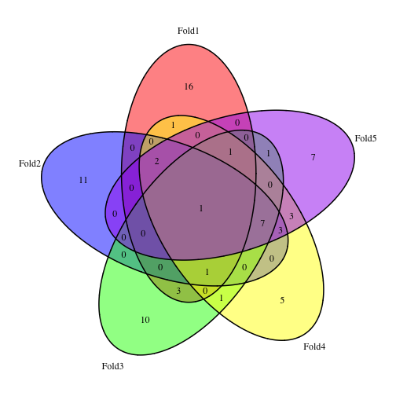

```r
all.results[["corr.del5"]] <- cv.del5.res[1:3]
fts <- cv.del5.res[[4]]

plot.new()
venn.plot <- venn.diagram(fts, filename = NULL, fill = c("red", "blue", "green",
    "yellow", "purple"), margin = 0.1)
grid.draw(venn.plot)
```

```r
(common.fts.del5 <- intersect(fts[[1]], intersect(fts[[2]], intersect(fts[[3]],
    intersect(fts[[4]], fts[[5]])))))
```

```
## [1] "DSCAM|1826_calculated"
```

Next look at deletions of chromosome 7:

```r
cv.del7.res <- svm.cv(rDat, factor(as.numeric(rDes$del_7)), factor(as.numeric(rDes$del_7)),
    K = 5, fs.method = "corr")
```

```
## Using automatic sigma estimation (sigest) for RBF or laplace kernel
## Using automatic sigma estimation (sigest) for RBF or laplace kernel
## Using automatic sigma estimation (sigest) for RBF or laplace kernel
## Using automatic sigma estimation (sigest) for RBF or laplace kernel
## Using automatic sigma estimation (sigest) for RBF or laplace kernel
```

```r
cv.del7.res[1:3]
```

```
## $acc
## [1] 0.9441
##
## $sens
## [1] 0.6667
##
## $spec
## [1] 0.981
```

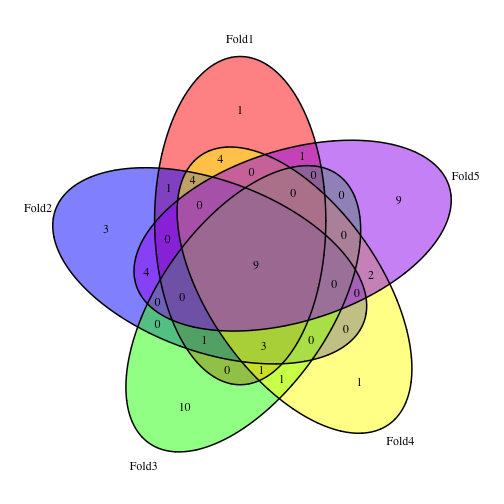

```r
all.results[["corr.del7"]] <- cv.del7.res[1:3]
fts <- cv.del7.res[[4]]

plot.new()
venn.plot <- venn.diagram(fts, filename = NULL, fill = c("red", "blue", "green",
    "yellow", "purple"), margin = 0.1)
grid.draw(venn.plot)
```

```r
(common.fts.del7 <- intersect(fts[[1]], intersect(fts[[2]], intersect(fts[[3]],
    intersect(fts[[4]], fts[[5]])))))
```

```
## [1] "MKRN1|23608_calculated"  "LUC7L2|51631_calculated"
## [3] "GSTK1|373156_calculated" "PDAP1|11333_calculated"
## [5] "FSCN3|29999_calculated"  "CASP2|835_calculated"
## [7] "PRKAG2|51422_calculated" "CPSF4|10898_calculated"
## [9] "ARF5|381_calculated"
```

Now get a sense of how many genes are shared between these 4 different sets:

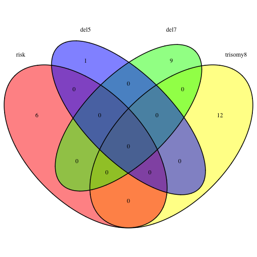

```r
fts.all <- list(risk = common.fts.risk, trisomy8 = common.fts.trisomy8, del5 = common.fts.del5,
    del7 = common.fts.del7)
plot.new()
venn.plot <- venn.diagram(fts.all, filename = NULL, fill = c("red", "yellow",
    "blue", "green"))
grid.draw(venn.plot)
```

## 6) Train svm to predict “Good” cytogenetic risk, use linear models for feature selection

Set up the data. Remove samples where the cytogenetic risk category is not determined, and set categories to good and not good:

```r
svmDes <- rDes[rDes$Cytogenetic_risk != "N.D.", ]
svm.labels <- mapvalues(svmDes$Cytogenetic_risk, c("Good", "Intermediate", "Poor"),
    c(1, 0, 0), warn_missing = TRUE)
svm.labels <- factor(svm.labels)
svm.levels <- mapvalues(svmDes$Cytogenetic_risk, c("Good", "Intermediate", "Poor"),
    c(3, 2, 1), warn_missing = TRUE)
svm.levels <- factor(svm.levels)
svmDat <- rDat[, rownames(svmDes)]
```

Run a 5-fold cross-validation for the data:

```r
cv.risk.res <- svm.cv(svmDat, svm.labels, svm.levels, K = 5, fs.method = "lm")
```

```
## Using automatic sigma estimation (sigest) for RBF or laplace kernel
## Using automatic sigma estimation (sigest) for RBF or laplace kernel
## Using automatic sigma estimation (sigest) for RBF or laplace kernel
## Using automatic sigma estimation (sigest) for RBF or laplace kernel
## Using automatic sigma estimation (sigest) for RBF or laplace kernel
```

```r
cv.risk.res[1:3]
```

```
## $acc
## [1] 0.983
##
## $sens
## [1] 0.9394
##
## $spec
## [1] 0.993
```

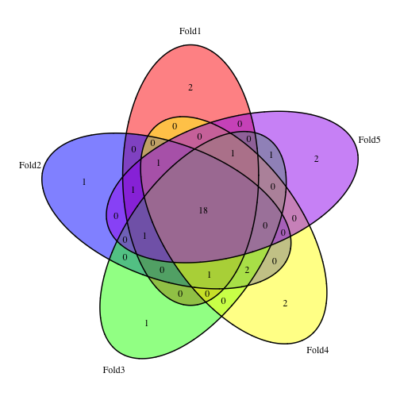

```r
all.results[["lm.good"]] <- cv.risk.res[1:3]
fts <- cv.risk.res[[4]]

plot.new()
venn.plot <- venn.diagram(fts, filename = NULL, fill = c("red", "blue", "green",
    "yellow", "purple"), margin = 0.1)
grid.draw(venn.plot)
```

```r
(common.fts.risk <- intersect(fts[[1]], intersect(fts[[2]], intersect(fts[[3]],
    intersect(fts[[4]], fts[[5]])))))
```

```
##  [1] "CPNE8|144402_calculated"  "HOXA7|3204_calculated"
##  [3] "HOXA6|3203_calculated"    "HOXA5|3202_calculated"
##  [5] "HOXA3|3200_calculated"    "HOXA4|3201_calculated"
##  [7] "HOXA9|3205_calculated"    "HOXA10|3206_calculated"
##  [9] "HOXA2|3199_calculated"    "FGFR1|2260_calculated"
## [11] "CYP7B1|9420_calculated"   "PDE4DIP|9659_calculated"
## [13] "HOXB5|3215_calculated"    "NKX2-3|159296_calculated"
## [15] "LPO|4025_calculated"      "RMND5B|64777_calculated"
## [17] "PRDM16|63976_calculated"  "HOXB6|3216_calculated"
```

## 7) Train svm to predict “Good” cytogenetic risk, using correlations for feature selection

Run a 5-fold cross-validation for the data:

```r
cv.risk.res <- svm.cv(svmDat, svm.labels, svm.levels, K = 5, fs.method = "corr")
```

```
## Using automatic sigma estimation (sigest) for RBF or laplace kernel
## Using automatic sigma estimation (sigest) for RBF or laplace kernel
## Using automatic sigma estimation (sigest) for RBF or laplace kernel
## Using automatic sigma estimation (sigest) for RBF or laplace kernel
## Using automatic sigma estimation (sigest) for RBF or laplace kernel
```

```r
cv.risk.res[1:3]
```

```
## $acc
## [1] 0.9602
##
## $sens
## [1] 0.8182
##
## $spec
## [1] 0.993
```

```r
all.results[["corr.good"]] <- cv.risk.res[1:3]
fts <- cv.risk.res[[4]]

plot.new()
venn.plot <- venn.diagram(fts, filename = NULL, fill = c("red", "blue", "green",
    "yellow", "purple"), margin = 0.1)
grid.draw(venn.plot)
```

[output not shown]

```r
(common.fts.risk <- intersect(fts[[1]], intersect(fts[[2]], intersect(fts[[3]],
    intersect(fts[[4]], fts[[5]])))))
```

```
## [1] "PDE4DIP|9659_calculated"  "PHKA1|5255_calculated"
## [3] "SDPR|8436_calculated"     "RECK|8434_calculated"
## [5] "IL7|3574_calculated"      "STARD10|10809_calculated"
```

## 8) Train svm to predict “Intermediate” cytogenetic risk, use linear models for feature selection

Set up the data. Remove samples where the cytogenetic risk category is not determined, and set categories to intermediate and not intermediate:

```r
svmDes <- rDes[rDes$Cytogenetic_risk != "N.D.", ]
svm.labels <- mapvalues(svmDes$Cytogenetic_risk, c("Good", "Intermediate", "Poor"),
    c(0, 1, 0), warn_missing = TRUE)
svm.labels <- factor(svm.labels)
svm.levels <- mapvalues(svmDes$Cytogenetic_risk, c("Good", "Intermediate", "Poor"),
    c(3, 2, 1), warn_missing = TRUE)
svm.levels <- factor(svm.levels)
svmDat <- rDat[, rownames(svmDes)]
```

Run a 5-fold cross-validation for the data:

```r
cv.risk.res <- svm.cv(svmDat, svm.labels, svm.levels, K = 5, fs.method = "lm",
    conf.mat.flip = TRUE)
```

```
## Using automatic sigma estimation (sigest) for RBF or laplace kernel
## Using automatic sigma estimation (sigest) for RBF or laplace kernel
## Using automatic sigma estimation (sigest) for RBF or laplace kernel
## Using automatic sigma estimation (sigest) for RBF or laplace kernel
## Using automatic sigma estimation (sigest) for RBF or laplace kernel
```

```r
cv.risk.res[1:3]
```

```
## $acc
## [1] 0.8693
##
## $sens
## [1] 0.8667
##
## $spec
## [1] 0.8713
```

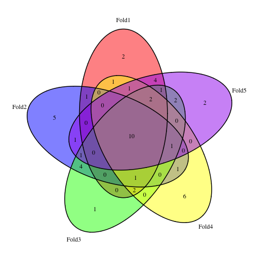

```r
all.results[["lm.intermediate"]] <- cv.risk.res[1:3]
fts <- cv.risk.res[[4]]

plot.new()
venn.plot <- venn.diagram(fts, filename = NULL, fill = c("red", "blue", "green",
    "yellow", "purple"), margin = 0.1)
grid.draw(venn.plot)
```

```r
(common.fts.risk <- intersect(fts[[1]], intersect(fts[[2]], intersect(fts[[3]],
    intersect(fts[[4]], fts[[5]])))))
```

```
##  [1] "NAV1|89796_calculated"    "SLC18A2|6571_calculated"
##  [3] "LASS4|79603_calculated"   "PBX3|5090_calculated"
##  [5] "HOXB6|3216_calculated"    "HOXB5|3215_calculated"
##  [7] "NKX2-3|159296_calculated" "IQCE|23288_calculated"
##  [9] "EVPL|2125_calculated"     "C7orf50|84310_calculated"
```

## 9) Train svm to predict “Intermediate” cytogenetic risk, using correlations for feature selection

Run a 5-fold cross-validation for the data:

```r
cv.risk.res <- svm.cv(svmDat, svm.labels, svm.levels, K = 5, fs.method = "corr",
    conf.mat.flip = TRUE)
```

```
## Using automatic sigma estimation (sigest) for RBF or laplace kernel
## Using automatic sigma estimation (sigest) for RBF or laplace kernel
## Using automatic sigma estimation (sigest) for RBF or laplace kernel
## Using automatic sigma estimation (sigest) for RBF or laplace kernel
## Using automatic sigma estimation (sigest) for RBF or laplace kernel
```

```r
cv.risk.res[1:3]
```

```
## $acc
## [1] 0.7841
##
## $sens
## [1] 0.6933
##
## $spec
## [1] 0.8515
```

```r
all.results[["corr.intermediate"]] <- cv.risk.res[1:3]
fts <- cv.risk.res[[4]]

plot.new()
venn.plot <- venn.diagram(fts, filename = NULL, fill = c("red", "blue", "green",
    "yellow", "purple"), margin = 0.1)
grid.draw(venn.plot)
```

[output not shown]

```r
(common.fts.risk <- intersect(fts[[1]], intersect(fts[[2]], intersect(fts[[3]],
    intersect(fts[[4]], fts[[5]])))))
```

```
## [1] "PDE4DIP|9659_calculated"  "PHKA1|5255_calculated"
## [3] "SDPR|8436_calculated"     "RECK|8434_calculated"
## [5] "IL7|3574_calculated"      "STARD10|10809_calculated"
```

## 10) Summarize results

```r
all.results.df <- data.frame(matrix(unlist(all.results), ncol = 3, byrow = TRUE))
rownames(all.results.df) <- names(all.results)
colnames(all.results.df) <- c("accuracy", "sensitivity", "specificity")
```

```r
all.results.xt <- xtable(all.results.df)
print(all.results.xt, type = "html")
```

|  | accuracy | sensitivity | specificity |
| --- | --- | --- | --- |
| lm.poor | 0.86 | 0.55 | 0.96 |
| lm.trisomy8 | 0.94 | 0.68 | 0.97 |
| lm.del5 | 0.96 | 0.62 | 0.99 |
| lm.del7 | 0.96 | 0.71 | 0.99 |
| corr.poor | 0.82 | 0.45 | 0.94 |
| corr.trisomy8 | 0.94 | 0.58 | 0.99 |
| corr.del5 | 0.92 | 0.19 | 0.99 |
| corr.del7 | 0.94 | 0.67 | 0.98 |
| lm.good | 0.98 | 0.94 | 0.99 |
| corr.good | 0.96 | 0.82 | 0.99 |
| lm.intermediate | 0.87 | 0.87 | 0.87 |
| corr.intermediate | 0.78 | 0.69 | 0.85 |